# Advanced Linear Regression : Case Study Reviewed

MYU Data Science

By Jean Marie Cimula

### Problem description

The ‘Ozone’ data from mlbench package contains the Los Angeles ozone pollution data collected in 1976. It is available as a data frame with 366 rows and 13 variables, that may be helpful to explain the ozone reading in the region. It is now up to us to find out which of the available variables would suit best to predict the ozone reading with maximum accuracy. The objective of this analysis is to accurately predict the ‘daily maximum one-hour average ozone reading’, using linear regression models. We will ensure this by making a 80:20 split of the data as development and validation samples, and use only the 80% sample for building linear models(training).

The models thus built will be used to predict the ozone reading on the 20% validation sample. With the actual ozone readings from 20% validation sample and model predictions thus computed, we will calculate the prediction accuracy and use it as one of the important parameters to decide the optimal model that suits this problem.

```r
#Loading libraries
library(e1071)                  #Skewness
library(PerformanceAnalytics)   #Correlogram (chart.Correlation)
library(Hmisc)                  #Missing value treatement (impute)
library(corrplot)               #Correlogram (corrplot)
library(party)                  #Selecting best variables (cforest)
library(Boruta)                 #Deciding if a variable is important (Boruta)
library(caret)                  #Boxcox transformation (BoxCoxTrans)
library(car)                    #VIF
library(DMwR)                   #knnImputation
library(mlbench)                #Ozone Data
library(DAAG)                   #Cross validation
library(relaimpo)               #Relative importance of predictors in lm mod
```

```r
#Prepare input data
###Create Input Datasets

data (Ozone, package="mlbench")  #Initialize the data
inputData <- Ozone  #Data from mlbench
#Assign names
names(inputData) <- c("Month", "DayOfMonth", "DayOfWeek", "OzoneReading", "PressureHeight", "WindSpeed", "Humidity", "TemperatureSandburg", "TemperatureElMonte", "InversionBaseHeight", "PressureGradient", "InversionTemperature", "Visibility")

#Segregate all continuous and categorical variables
#Place all continuous vars in ipDataCnt
ipDataCnt <- inputData[, c("PressureHeight", "WindSpeed", "Humidity", "TemperatureSandburg", "TemperatureElMonte", "InversionBaseHeight", "PressureGradient", "InversionTemperature", "Visibility")]

#Place all categorical variables in ipDataCat
ipDataCat <- inputData[, c("DayOfMonth","DayOfWeek")]

#Create the response data frame
ipDataResponse <- data.frame(OzoneReading=inputData[, "OzoneReading"])
respName <- "OzoneReading"  #name of response variable
response <- inputData[, respName]  #response variable as a vector
```

### Exploratory analysis

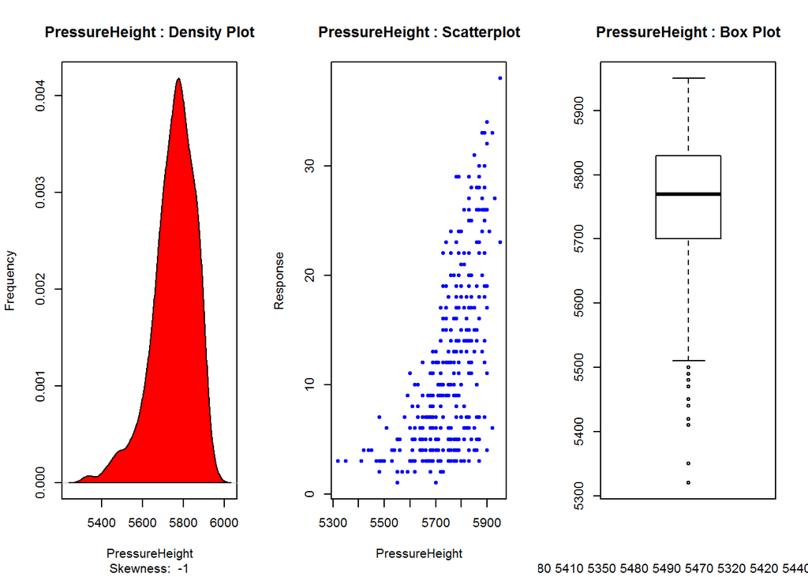

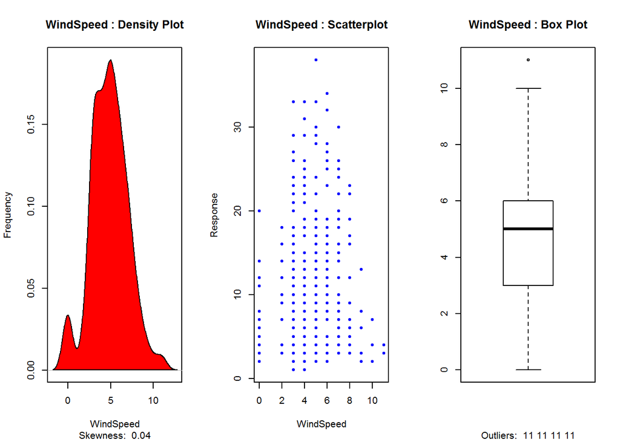

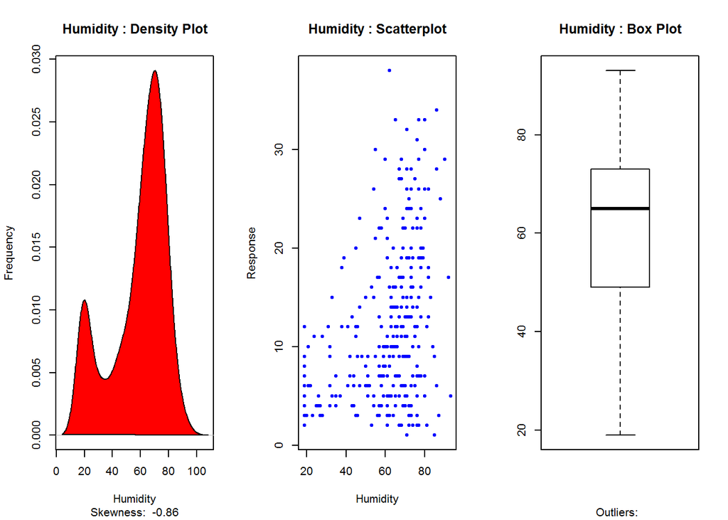

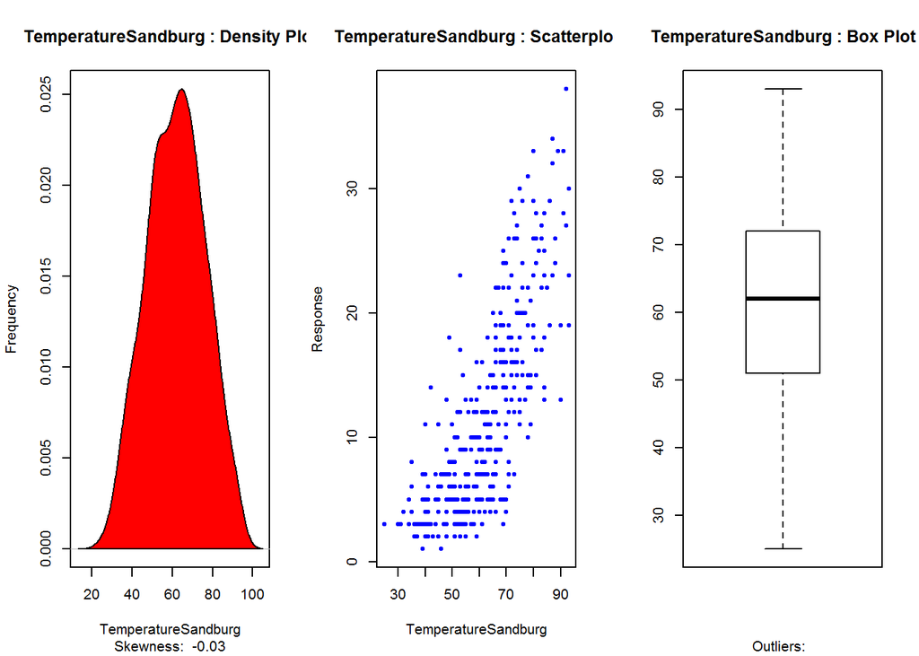

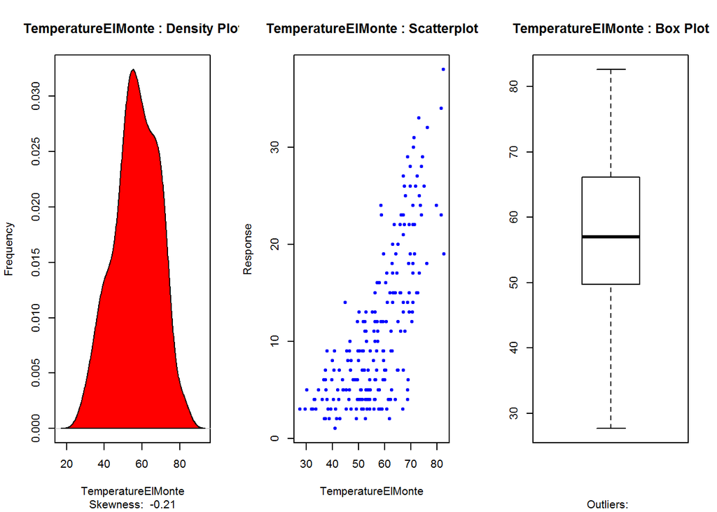

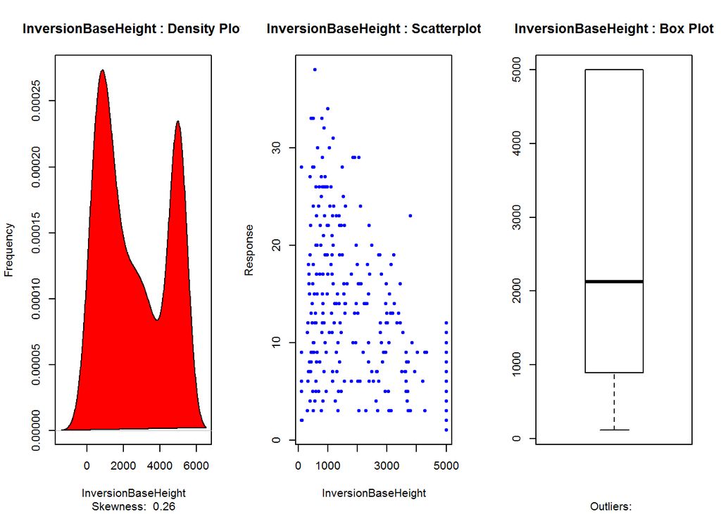

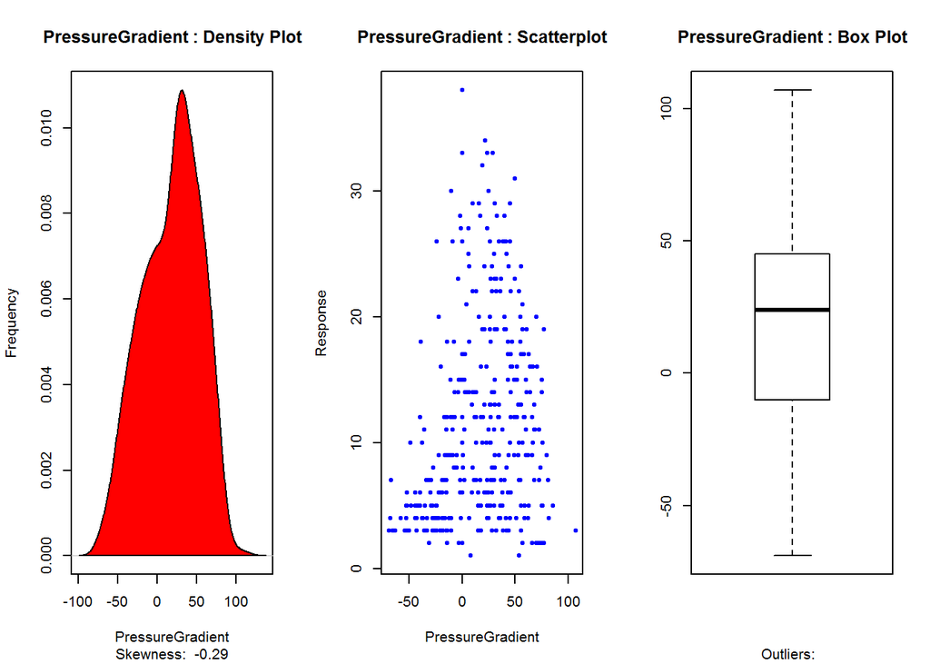

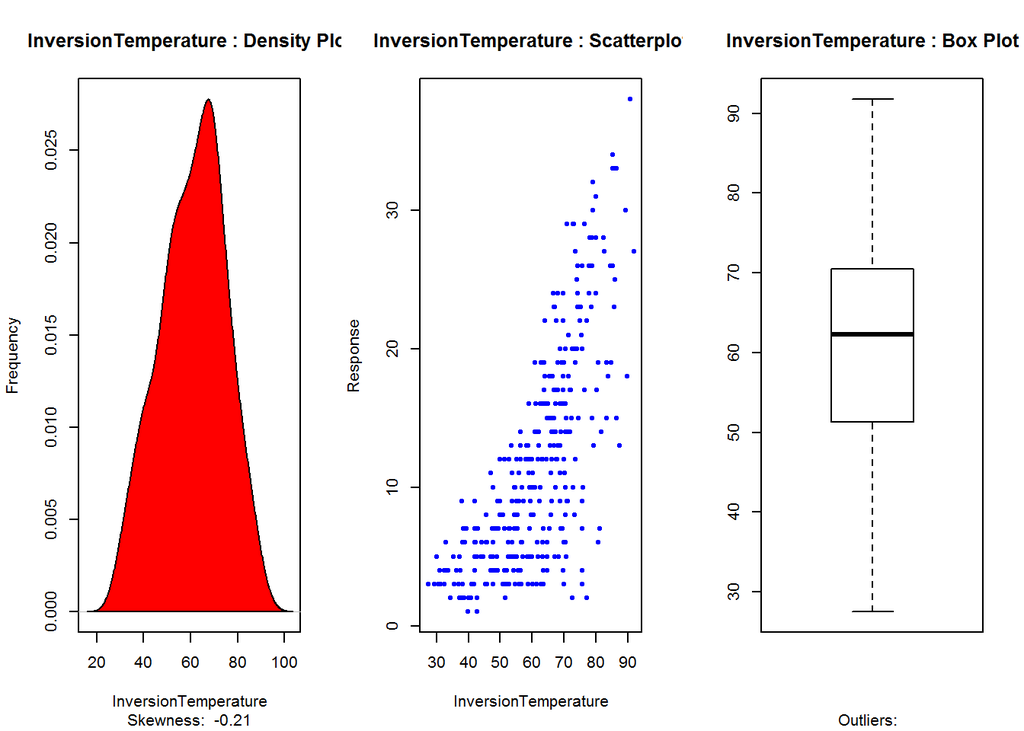

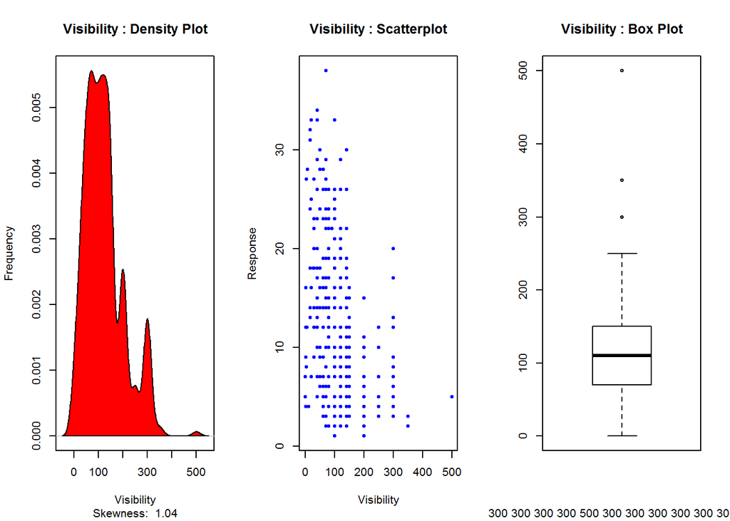

```r
#Generate plots: Density, Scatter, Box plots
#Set up your working directory here, to a location where you want to store plots.

  for (k in names(ipDataCnt)){

             x <- as.numeric (ipDataCnt[, k])
             Skewness <- round(skewness(x), 2)  #calc skewness
             dens <- density(x, na.rm=T)  #density func
             par(mfrow=c(1, 3))  #setup plot-area in 3 columns

             #Density plot
             plot(dens, type="l", col="red", ylab="Frequency", xlab = k, main = paste(k, ": Density Plot"),sub=paste("Skewness: ", Skewness))
             polygon(dens, col="red")

             #Scatterplot
             plot(x, response, col="blue", ylab="Response", xlab = k, main = paste(k, ": Scatterplot"), pch=20)
             abline(response ~ x)
             boxplot(x, main=paste(k, ": Box Plot"), sub=paste("Outliers: ", paste(boxplot.stats(x)$out, collapse=" ")))
}
```

###Oultier analysis

```r
#Method 1: If you choose to remove the outliers (not recommended)
x <- x[!x %in% boxplot.stats(x)$out]  # NOT run!

#Method 2: Replace outliers with NAs, be be filled up later during missing value treatment.

repOutlierMissing <- function(x, na.rm = TRUE, ...){

                      qnt <- quantile(x, probs=c(.25, .75), na.rm = na.rm, ...)
                      H <- 1.5 * IQR(x, na.rm = na.rm)  #Threshold
                      y <- x
                      y[x < (qnt[1] - H)] <- NA
                      y[x > (qnt[2] + H)] <- NA
                      return(y)
                  }
ipDataCnt <- as.data.frame (sapply(ipDataCnt, repOutlierMissing))  #this will make outliers as NA

#Re-assemble inputdata with the outlier corrected part
inputData <- cbind(ipDataResponse, ipDataCnt, ipDataCat)  #column bind the response, continuous and categorical predictors
```

### Missing value treatment

```r
#Apply the missing value treatment
#Method 1: Replace missing values with mean (NOT Run)
ipDataCntMatrix <- sapply(ipDataCnt, FUN=function(x){impute(x, mean)})#Missing values with the mean using 'impute' func from 'Hmisc' pkg

ipDataCnt <- as.data.frame(ipDataCntMatrix)  #store as dataframe

#Method 2: k-Nearest neighbor imputation method - Applied!
# Impute all except the response variable.

if( anyNA(inputData)) {
              # missing value treatment
              inputData[, !names(inputData) %in% respName] <- knnImputation(inputData[, !names(inputData) %in% respName])
}
```

### Correlation analysis and Summary

The correlogram is a graphical representation of correlation amongst all combinations of response and predictor variables. The investigator may choose to pick variables that have high correlation with the response based on a pre-determined cutoff. But we do not do that filtering here, since it is possible that a variable with relatively lower correlation can prove significant and valuable in regression models to capture unexplained variations, even if they are of ‘lower’ importance.

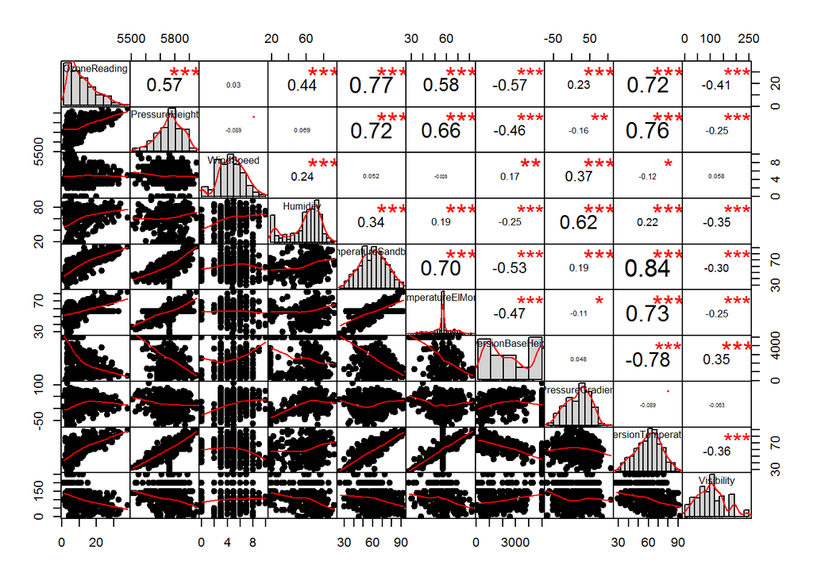

```r
par (mfrow=c(1,1))
ipDataRespCntNALess <- na.omit(cbind(ipDataResponse, ipDataCnt))  #remove rows with missing values
chart.Correlation(ipDataRespCntNALess, histogram=TRUE, pch=19)  #plot correlogram
```

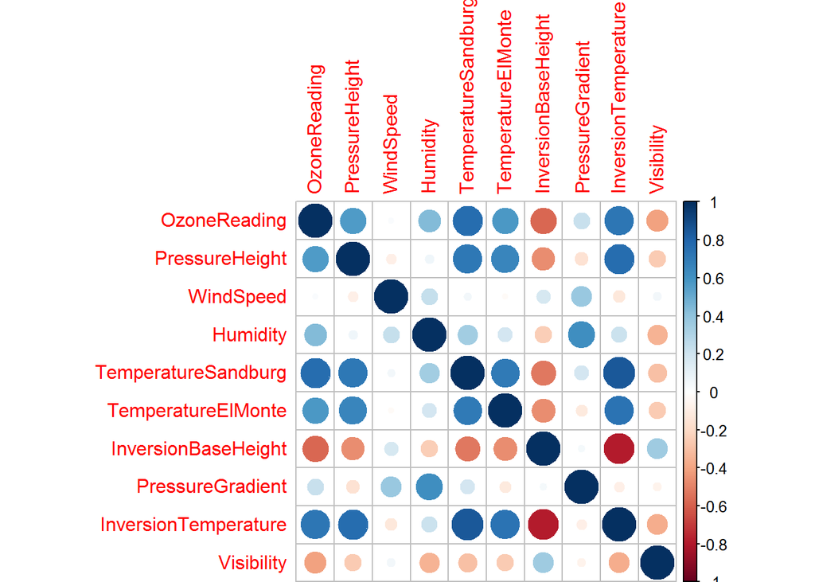

```r
corrplot(cor(ipDataRespCntNALess), method="circle", is.corr=TRUE)
```

```r
#Get and store the summary files
sapply(inputData, summary)  #get summary statistics for all columns
```

```
## $OzoneReading
##    Min. 1st Qu.  Median    Mean 3rd Qu.    Max.    NA's
##    1.00    5.00    9.00   11.53   16.00   38.00       5
##
## $PressureHeight
##    Min. 1st Qu.  Median    Mean 3rd Qu.    Max.
##    5510    5700    5770    5759    5830    5950
##
## $WindSpeed
##    Min. 1st Qu.  Median    Mean 3rd Qu.    Max.
##   0.000   3.000   5.000   4.801   6.000  10.000
##
## $Humidity
##    Min. 1st Qu.  Median    Mean 3rd Qu.    Max.
##   19.00   47.25   64.00   58.29   73.00   93.00
##
## $TemperatureSandburg
##    Min. 1st Qu.  Median    Mean 3rd Qu.    Max.
##   25.00   51.25   62.00   61.90   72.00   93.00
##
## $TemperatureElMonte
##    Min. 1st Qu.  Median    Mean 3rd Qu.    Max.
##   27.68   51.28   57.11   57.39   64.95   82.58
##
## $InversionBaseHeight
##    Min. 1st Qu.  Median    Mean 3rd Qu.    Max.
##     111     899    2168    2579    5000    5000
##
## $PressureGradient
##    Min. 1st Qu.  Median    Mean 3rd Qu.    Max.
##  -69.00   -9.75   24.00   17.75   45.00  107.00
##
## $InversionTemperature
##    Min. 1st Qu.  Median    Mean 3rd Qu.    Max.
##   27.50   51.62   62.78   61.08   70.49   91.76
##
## $Visibility
##    Min. 1st Qu.  Median    Mean 3rd Qu.    Max.
##     0.0    70.0   100.0   108.6   148.0   250.0
##
## $DayOfMonth
##  1  2  3  4  5  6  7  8  9 10 11 12 13 14 15 16 17 18 19 20 21 22 23 24 25
## 12 12 12 12 12 12 12 12 12 12 12 12 12 12 12 12 12 12 12 12 12 12 12 12 12
## 26 27 28 29 30 31
## 12 12 12 12 11  7
##
## $DayOfWeek
##  1  2  3  4  5  6  7
## 52 52 52 53 53 52 52
```

### Box Cox Transformation for Continuous variables

Upon performing outlier treatment, you can expect the skewness of the variable to improve. But not always. Sometimes a box-cox transformation of the response variable is preferable to reduce the skewness and make it closer to a normal distribution. While the variable gets transformed, ranking order of the variable remains the same after the transformation.

### Why does a highly skewed non-normal response variable matter?

Because, for the long tailed region of the response, there is a larger variance. This also means, more predictors are expected to have a stronger effect while explaining the larger variance part of the response variable, thereby creating a bias. This can affect all the estimates resulting in spurious models. It can also be argued that a high skewness is a consequence of heteroscedasticity (non-constant variance).

Therefore, if the skewness does not improve after treating the outliers, consider performing a box-cox transformation especially when k-fold cross-validation reveals inconsistent results. Note that, it is not mandatory to apply box-cox transformation on all variables that are skewed. It is up to the best judgement of the investigator to decide if box-cox transformation is indeed needed on a variable.

Nevertheless, just so you know how a box cox transform is done, below is the procedure. As a default, box-cox transformation in the response variable is sufficient, but here, I have chosen to apply it on variables that have a skewness > 1, even after outlier corrections are applied.

```r
skewness(ipDataResponse, na.rm=T)  # 0.878864
```

```
## [1] 0.8825285
```

```r
#Transforming the predictor variables

boxcoxTransformedVars <- character(0)  #variables that underwent box-cox transformation collects here.

 for (colname in colnames(ipDataCnt[, -1])) {

                     x <- ipDataCnt[, colname]
                     #Check for high skewness.
                     if(abs(skewness(x, na.rm=T)) > 1){

                                      boxcoxMod <- BoxCoxTrans(x) #calculates lambda value and store in a model
                                      boxcoxTransformedVars <<- c(boxcoxTransformedVars, colname)
                                      ipDataCnt[, colname] <- predict(boxcoxMod, x)  #calculate transformed variable
                      }

 }
#Selecting signifiant variables (continuous) - checking for p-Values

sigPredCnt <- character()  #initialise output. Significant preds will accrue here

for (predName in names(ipDataCnt)) {

           pred <- inputData[, predName]
           mod <- lm(response ~ pred)  #build linear model with only current predictor
           p_value <- summary(mod)$coefficients[, 4][2]  # capture p-Value
                  #check for significance
                  if (p_value < 0.1 & p_value > 0) {
                             #if selected, bind the predictor name if main output
                             sigPredCnt <- c (sigPredCnt, predName)

                  }

}

ipDataCntSig <- inputData[, names(inputData) %in% sigPredCnt]  #filter selected predictors

#Selecting signifiant variables (categorical) - checking for chi-sq test

sigPredCat <- character()  #initialise output. Significant preds will accrue here

for (predName in names(ipDataCat)) {

              pred <- inputData[, predName]
              chi_sq <- invisible(suppressWarnings(chisq.test(table(response, pred))))  #perform chi-Squared tes
              p_value <- chi_sq[3]  #capture p-Value
                         #check for significance
                         if (p_value < 0.1 & p_value > 0) {

                                     sigPredCat <- c (sigPredCat, predName)
                          }

}

ipDataCatSig <- as.data.frame(inputData[, names(inputData) %in% sigPredCat])
colnames(ipDataCatSig) <- sigPredCat  #assign column names

#Combine the response, continuous significant predictors, categorical significant predictors
inputDataSigF <- cbind(response, ipDataCntSig, ipDataCatSig)
```

### Feature selection

```r
#Part 1: Boruta: Decide if a variable is important or not
# Decide if a variable is important or not using Boruta

borutaOutput <- Boruta(response ~ ., data=na.omit(inputDataSigF), doTrace=2)  #perform Boruta search
borutaSigF <- names(borutaOutput$finalDecision[borutaOutput$finalDecision %in% c("Confirmed", "Tentative")])  #collect Confirmed and Tentative variables

#Part 2: Estimate important variables based on mean drop in accuracy - using cforest
#Selecting best variables (variable selection using cforest)

cf1 <- cforest(response ~ . , data= na.omit(inputDataSigF[, names(inputDataSigF) %in% c(borutaSigF, "response")]), control=cforest_unbiased(mtry=2,ntree=50)) #fit the random forest
impVars <- sort(varimp(cf1), decreasing=T) #get variable importance

# Pick top 7. Adjust this as per your needs. More variables will take more computational time.

impVars <- if(length(impVars) > 7){  impVars[1:7] } else { impVars}

#Part 3: Removing multicollinearity
varConsFilter <- names(impVars)[!names(impVars) %in% names(ipDataCatSig)]  #exclude categoricals
fullForm <- (paste ("response ~ ", paste (varConsFilter, collapse=" + "), sep=""))  #model formula
fullMod  <- lm(as.formula(fullForm), data=inputDataSigF)  #build linear model

allVIF <- try(vif(fullMod), silent=TRUE)  #get all vifs

#if vif of any of the variables in model is greater than threshold (4), drop the max VIF variable and build model again, until all variables have VIF less than threshold.

    if(class(allVIF) != "try-error"){

                         allVIF <- as.data.frame(allVIF)  #cast as a dataframe
                         # check if there are more > 2 rows, max-VIF exceeds 4 and not of 'try-error' clas

                         while((nrow(allVIF) > 2)& (max(allVIF[, 1]) > 4)  &  (class(allVIF) != "try-error")) {
                                      #find max VIF variable
                                      rmVars <- rownames(allVIF)[which(allVIF[, 1] == max(allVIF[, 1]))]
                                      impVars <- impVars[!names(impVars) %in% rmVars]  #remove
                                      fullForm <- paste ("response ~ ", paste (names(impVars), collapse=" + "), sep="")  #new formula
                                      fullMod <- lm(as.formula(fullForm), data=inputDataSigF)  #re-build model with new formula
                                      allVIF <- try(as.data.frame(vif(fullMod)), silent=TRUE)  # get all vifs

                        }
}

vFilterVars <- names(fullMod$model)[!names(fullMod$model) %in% "response"]
```

### Create all combinations of selected variables that will go into models as predictors

Lets build all combinations of the selected predictor variables, for building models of all sizes. If you wish to limit the maximum size the model, set the size in maxModelSize variable.

```r
#create all combinations of predictors

maxModelSize <- length(vFilterVars)

cmbMatrix <- matrix(ncol=maxModelSize)  #initialise final output

for (n in 1:length(vFilterVars)){

              cmbMatFilter <- t(combn(vFilterVars, n))  #all combinations of variable
              nrOut <- nrow(cmbMatFilter)
              ncOut <- length(vFilterVars)
              nrNA  <- nrOut
              ncNA  <- ncOut-ncol(cmbMatFilter)
              naMatr<- matrix(rep(NA, nrNA*ncNA), nrow=nrNA, ncol=ncNA)
              out   <- cbind(cmbMatFilter, naMatr)
              cmbMatrix <- rbind(cmbMatrix, out)
}

cmbMatrix <- cmbMatrix[-1, ]  #remove the first row that has all NA

## Split training and test data (development and validation)

set.seed(100)
trainingIndex <- sample(1:nrow(inputDataSigF), 0.8*nrow(inputDataSigF))  #random sample rows for training data
inputDataSigFTrain <- na.omit(inputDataSigF[trainingIndex, ])  #remove NA's in response variable
inputDataSigFTesting <- na.omit(inputDataSigF[-trainingIndex, ])  #omitting NA's, since we need to calculate prediction accuracy
```

### Building all the linear models and diagnostics

Now that we have all the possible combinations for predictors, we can expect to generate several good models from this mix. In the code that follows, you will first build the model and capture the summary of the model in a variable (currSumm). Then, the diagnostic parameters such as R-sq, p-Value, AIC etc are captured. Post that, the Influential observations and accuracy measures are calculated on the training and test data sets. Finally, we perform the k-Fold cross validation and capture the mean-squared error for the model.

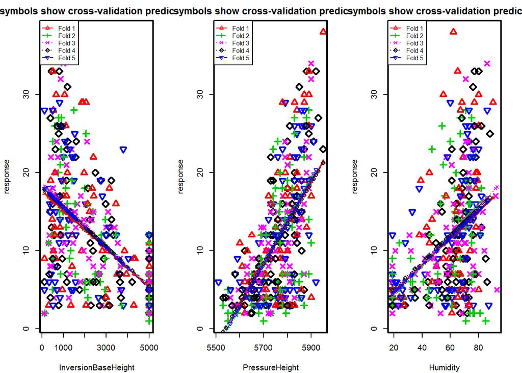

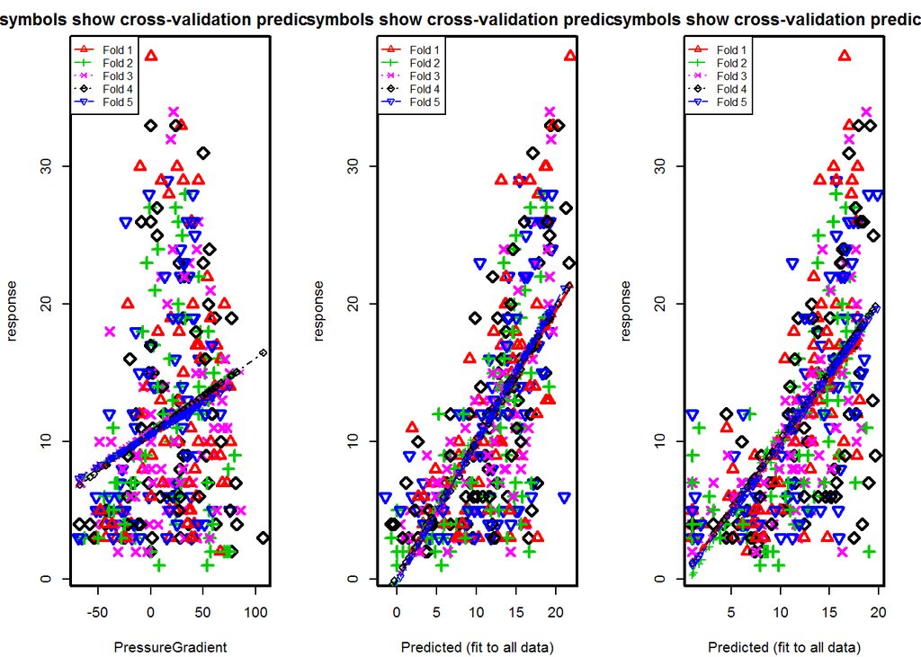

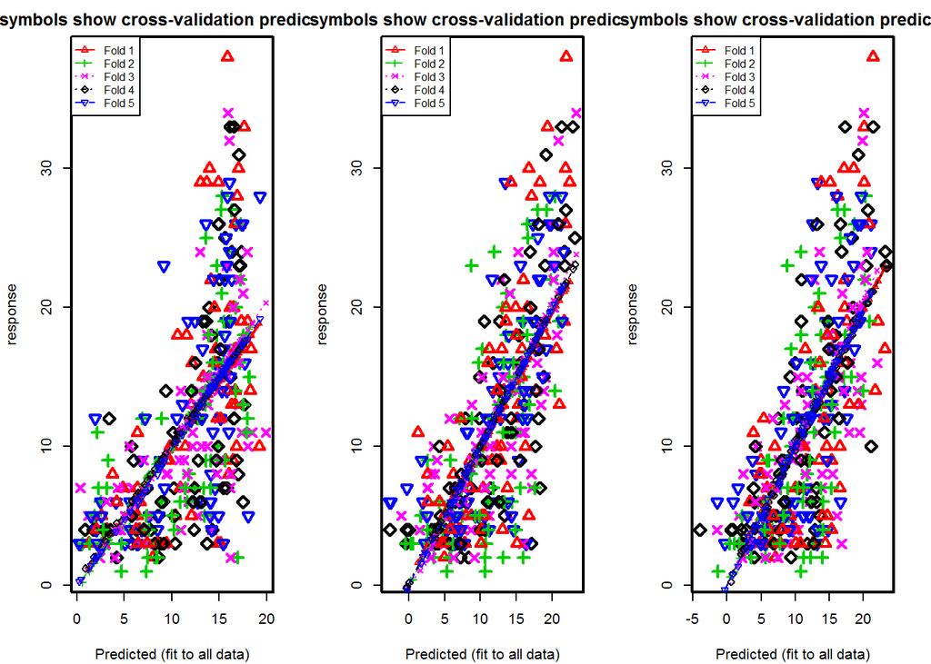

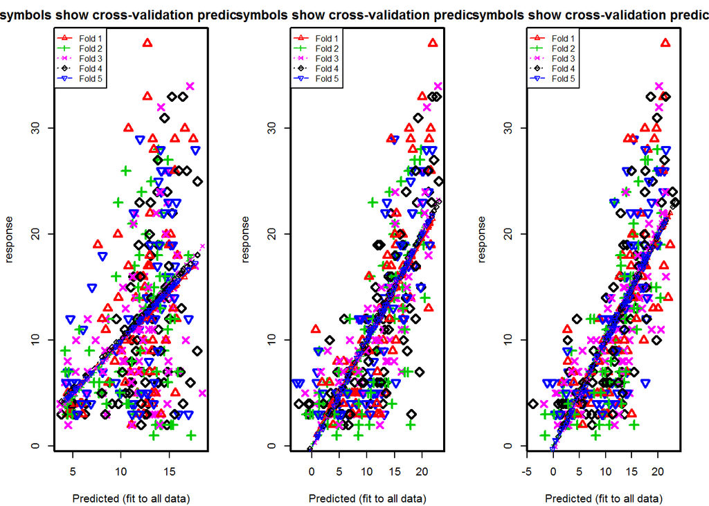

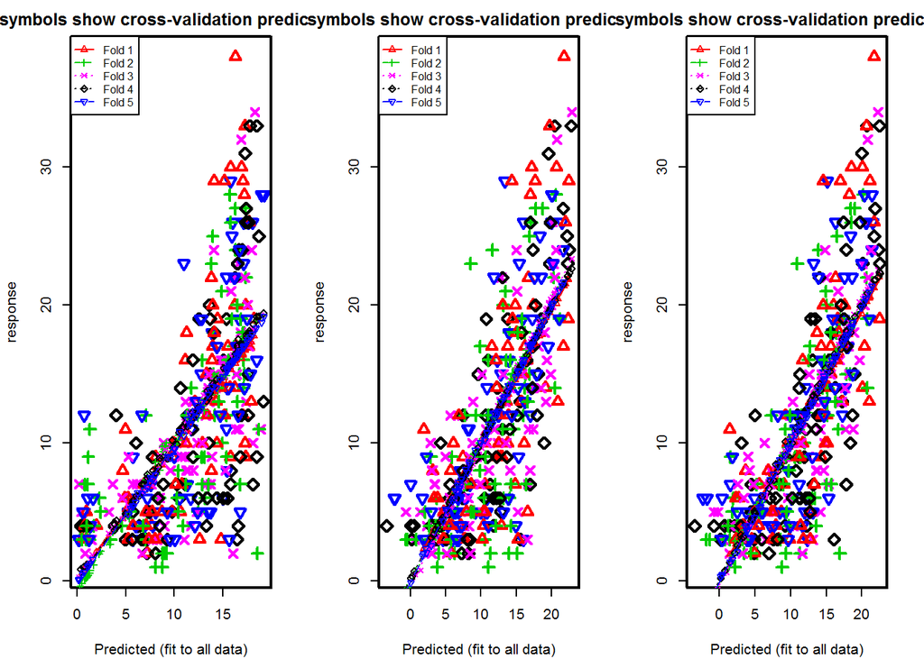

```r
#BUILD THE LINEAR MODELS

Final_Output <- data.frame()  #initialise the final output dataframe
par (mfrow=c(1,3))  #set margins

for (rownum in 1:nrow(cmbMatrix)){
            ##Build model for current formula from cmbMatrix
            preds <- na.omit(cmbMatrix[rownum, ])  #get the predictor names
            form <- paste ("response ~ ", paste (preds, collapse=" + "), sep="")  #model formul
            currMod <- lm(as.formula(form), data=inputDataSigFTrain)  #build the linear model
            currSumm <- summary(currMod)  #model summary

            ##Diagnostic parameters-
            FStats <- currSumm$fstatistic[1]  #Fstatistic
            f <- currSumm$fstatistic  #parameters for model p-value calc
            modelP <- pf(f[1], f[2], f[3], lower=FALSE)  #model p-Value
            rSQ  <- currSumm[8]  #R-Squared
            ArSQ <- currSumm[9]  #adj R-Squared
            aic  <- AIC(currMod)  #AIC
            bic  <- BIC(currMod)  #BIC

            ## Get Influential Observations-
            cutoff <- 4/(nrow(inputDataSigFTrain)-length(currMod$coefficients)-2)  #cooks.distance cutoff
            infObsRows <- paste(which(cooks.distance(currMod) > cutoff), collapse=" ")  #caputure influential observations

            ## Calculate accuracy measures on Development sample-
            trainMap  <- mean((abs(currMod$residuals))/abs(na.omit(inputDataSigFTrain$response))) * 100  #MAPE
            actFitted <- data.frame(actuals=inputDataSigFTrain$response, fitted=currMod$fitted)
            minVals   <- apply(actFitted, 1, min)
            maxVals   <- apply(actFitted, 1, max)
            trainMinMax <- minVals/maxVals
            trainMinMaxAcc <- mean(trainMinMax)

            ## Calculate accuracy measures on Validation sample-
            predicteds <- predict(currMod, inputDataSigFTesting)  #predict for test data
            predMap    <- mean((abs(inputDataSigFTesting$response - predicteds)/abs(inputDataSigFTesting$response))) * 100  #calculate predicted mape
            actual_predicteds <- data.frame(actuals=inputDataSigFTesting$response, predicted=predicteds)
            minVals <- apply(actual_predicteds, 1, min)
            maxVals <- apply(actual_predicteds, 1, max)
            predMinMax <- minVals/maxVals
            predMinMaxAcc <- mean(minVals/maxVals) #min-max accuracy on test data

            ##Perform k-Fold cross-validation-
            cvResults <- suppressWarnings(CVlm(na.omit(inputDataSigF), form.lm=currMod, m=5, dots=FALSE, seed=29, legend.pos="topleft", printit=FALSE))
            meanSQError <- attr(cvResults, 'ms')

            ##Collect all stats for Final Output-
            currOutput <- data.frame(formula=form, rSQ=rSQ, ArSQ=ArSQ, AIC=aic, BIC=bic, Model.pValue= modelP,
                          F.Statistic=f[1], training.mape=trainMap, predicted.mape=predMap, training.minmax.accuracy = trainMinMaxAcc, predicted.minmax.accuracy=predMinMaxAcc, influential.obs = infObsRows, k_fold_ms=meanSQError)

            #Final Output
            Final_Output <- rbind(Final_Output, currOutput)

            ##Print output so they get accumulated in 'All_Models_In_Combos.txt'
            names(actFitted) <- c("actuals", "predicted")
            actPredAll <- rbind(actFitted, actual_predicteds)
            print (currSumm)
            print (vif(currMod))
            print (actpPred <- cbind(actPredAll, na.omit(inputDataSigF)[, preds]))
}
```

```r
write.csv(Final_Output, "Final_Regression_Output.csv", row.names=F)  # Export
```

```r
rownum=15  #row number of best model from Final_Regression_Output.csv

preds <- na.omit(cmbMatrix[rownum, ])  #get the predictor names
form  <- paste ("response ~ ", paste (preds, collapse=" + "), sep="")  #model fornula
currMod <- lm(as.formula(form), data=inputDataSigFTrain)  #build llinear model
currSumm <- summary(currMod)  #model summary
vif(currMod)  #variance inflation factor
```

```
## InversionBaseHeight      PressureHeight            Humidity
##              1.5460              1.4330              1.9452
##    PressureGradient
##              1.8551
```

# Get influential observations

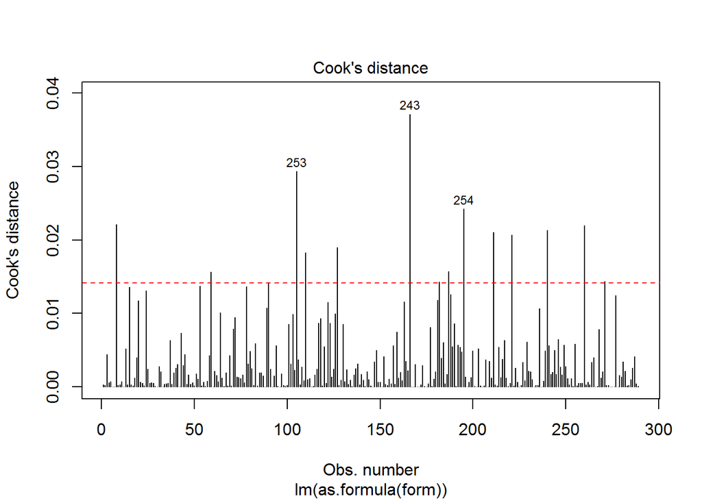

```r
#Get Influential Observations
cutoff <- 4/(nrow(inputDataSigFTrain)-length(currMod$coefficients)-2)
plot (currMod, which=4, cook.levels=cutoff)
abline (h=cutoff, lty=2, col="red")
```

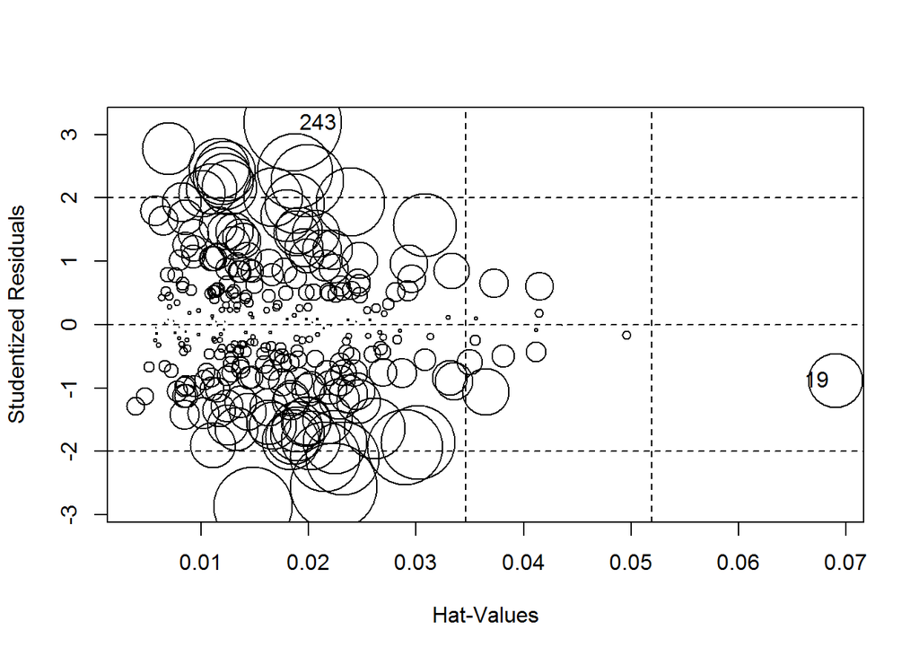

```
##        StudRes        Hat      CookD
## 19  -0.8830961 0.06901362 0.01157109
## 243  3.1844485 0.01855175 0.03714138
```

```r
influencePlot (currMod)  #Influence plot for best model fits
```